# zadanie2_bagin.R

samuelbagin

2026-10-07

# zadanie 2 - spotreba staveniska

```r
library(readxl)
library(Rmisc)
```

```r
library(mosaic)
library(plotrix)
library(ggplot2)
library(viridisLite)

set.seed(2026)
farby <- viridis(3, end = 0.8)
```

# 1. import a uprava dat

```r
data <- as.data.frame(read_xlsx("Kontajner_spotreba.xlsx", sheet = "Kontajnery"))
names(data) <- tolower(names(data))
str(data)
```

```
## 'data.frame':    8904 obs. of  3 variables:
##  $ datum   : POSIXct, format: "2022-12-01" "2022-12-01" ...
##  $ cas     : POSIXct, format: "1899-12-31 00:00:00" "1899-12-31 01:00:00" ...
##  $ spotreba: num  7984 7966 8062 8057 8066 ...
```

```r
head(data)
```

```
##        datum                 cas spotreba
## 1 2022-12-01 1899-12-31 00:00:00 7984.075
## 2 2022-12-01 1899-12-31 01:00:00 7966.195
## 3 2022-12-01 1899-12-31 02:00:00 8062.485
## 4 2022-12-01 1899-12-31 03:00:00 8056.656
## 5 2022-12-01 1899-12-31 04:00:00 8066.186
## 6 2022-12-01 1899-12-31 05:00:00 7991.026
```

```r
colSums(is.na(data))
```

```
##    datum      cas spotreba
##        0        0        0
```

```r
data$datum <- as.Date(data$datum, tz = "UTC")
data$cas <- format(data$cas, "%H:%M:%S", tz = "UTC")
data$datum_cas <- as.POSIXct(paste(data$datum, data$cas), tz = "UTC")
head(data)
```

```
##        datum      cas spotreba           datum_cas
## 1 2022-12-01 00:00:00 7984.075 2022-12-01 00:00:00
## 2 2022-12-01 01:00:00 7966.195 2022-12-01 01:00:00
## 3 2022-12-01 02:00:00 8062.485 2022-12-01 02:00:00
## 4 2022-12-01 03:00:00 8056.656 2022-12-01 03:00:00
## 5 2022-12-01 04:00:00 8066.186 2022-12-01 04:00:00
## 6 2022-12-01 05:00:00 7991.026 2022-12-01 05:00:00
```

```r
range(data$datum)
```

```
## [1] "2022-12-01" "2023-12-06"
```

```r
sum(duplicated(data[c("datum", "cas", "spotreba")]))
```

```
## [1] 0
```

```r
data[duplicated(data$datum_cas) | duplicated(data$datum_cas, fromLast = TRUE), ]
```

```
##           datum      cas spotreba           datum_cas
## 7970 2023-10-29 02:00:00  2694.65 2023-10-29 02:00:00
## 7971 2023-10-29 02:00:00  5537.84 2023-10-29 02:00:00
```

```r
data[substr(data$cas, 4, 8) != "00:00", ]
```

```
##           datum      cas spotreba           datum_cas
## 1624 2023-02-06 15:31:00 27751.57 2023-02-06 15:31:00
```

```r
table(table(data$datum))
```

```
##
##  24
## 371
```

data obsahuju 8904 merani od 1. 12. 2022 do 6. 12. 2023 bez chybajucich hodnot a uplne zhodnych zaznamov. zaznam 6. 2. 2023 ma cas 15:31 (ma byt 15:00), a dna 29. 10. 2023 sa cas 02:00 opakuje s odlisnou spotrebou, zatial co 01:00 chyba. vsetky zaznamy zostavaju zachovane, pretoze pricinu casovych nezrovnalosti nepozname.

```r
max(data$spotreba)
```

```
## [1] 27751.57
```

# 2. casove premenne

```r
data$den_merania <- as.integer(data$datum - min(data$datum)) + 1
data$hodina <- factor(substr(data$cas, 1, 2), levels = sprintf("%02d", 0:23))
data$den_tyzdna <- factor(format(data$datum, "%u"), levels = 1:7,
                          labels = c("pondelok", "utorok", "streda", "stvrtok", "piatok", "sobota", "nedela"))

data$typ_dna <- factor(ifelse(as.integer(data$den_tyzdna) <= 5, "pracovny den", "vikend"),
                       levels = c("pracovny den", "vikend"))
data$mesiac <- factor(format(data$datum, "%Y-%m"))
head(data)
```

```
##        datum      cas spotreba           datum_cas den_merania hodina
## 1 2022-12-01 00:00:00 7984.075 2022-12-01 00:00:00           1     00
## 2 2022-12-01 01:00:00 7966.195 2022-12-01 01:00:00           1     01
## 3 2022-12-01 02:00:00 8062.485 2022-12-01 02:00:00           1     02
## 4 2022-12-01 03:00:00 8056.656 2022-12-01 03:00:00           1     03
## 5 2022-12-01 04:00:00 8066.186 2022-12-01 04:00:00           1     04
## 6 2022-12-01 05:00:00 7991.026 2022-12-01 05:00:00           1     05
##   den_tyzdna      typ_dna  mesiac
## 1    stvrtok pracovny den 2022-12
## 2    stvrtok pracovny den 2022-12
## 3    stvrtok pracovny den 2022-12
## 4    stvrtok pracovny den 2022-12
## 5    stvrtok pracovny den 2022-12
## 6    stvrtok pracovny den 2022-12
```

```r
table(data$hodina)
```

```
##
##  00  01  02  03  04  05  06  07  08  09  10  11  12  13  14  15  16  17  18  19
## 371 370 372 371 371 371 371 371 371 371 371 371 371 371 371 371 371 371 371 371
##  20  21  22  23
## 371 371 371 371
```

```r
table(data$den_tyzdna)
```

```
##
## pondelok   utorok   streda  stvrtok   piatok   sobota   nedela
##     1272     1272     1272     1272     1272     1272     1272
```

```r
table(data$typ_dna)
```

```
##
## pracovny den       vikend
##         6360         2544
```

```r
table(data$mesiac)
```

```
##
## 2022-12 2023-01 2023-02 2023-03 2023-04 2023-05 2023-06 2023-07 2023-08 2023-09
##     744     744     672     744     720     744     720     744     744     720
## 2023-10 2023-11 2023-12
##     744     720     144
```

hodiny maju 371 merani okrem hodiny 01 s 370 a hodiny 02 s 372 zaznamami, kazdy den tyzdna ma 1272 merani. pracovne dni zahrnaju pondelok az piatok vratane sviatkov a zaznam 15:31 patri do hodiny 15. december 2023 obsahuje iba sest dni a zostava oddeleny od decembra 2022.

# 3. intervaly spolahlivosti

## vyvoj spotreby

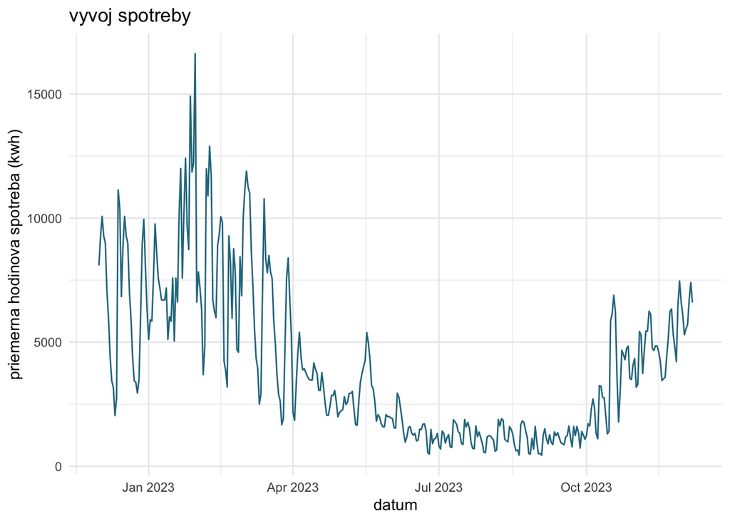

```r
spotreba <- data$spotreba
denne_priemery <- aggregate(spotreba ~ datum, data = data, mean)
ggplot(denne_priemery, aes(datum, spotreba)) +
  geom_line(color = farby[2], linewidth = 0.5) + theme_minimal() +
  labs(title = "vyvoj spotreby", x = "datum", y = "priemerna hodinova spotreba (kwh)")
```

zimne hodnoty su vyssie nez letne a celkovy priemer skryva vyrazne zmeny pocas roka. bez udajov o teplote a prevadzke nemozno urcit pricinu tohto vzoru.

## rozdelenie spotreby

```r
summary(spotreba)
```

```
##    Min. 1st Qu.  Median    Mean 3rd Qu.    Max.
##   248.1  1358.0  3102.6  4073.1  5760.3 27751.6
```

```r
sd(spotreba)
```

```
## [1] 3575.375
```

```r
moments::skewness(spotreba)
```

```
## [1] 1.646864
```

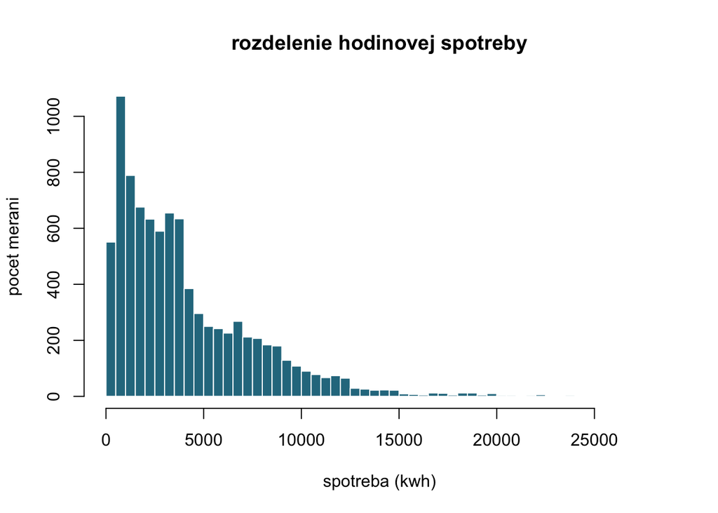

```r
hist(spotreba, breaks = 50, col = farby[2], border = "white",
     main = "rozdelenie hodinovej spotreby", xlab = "spotreba (kwh)", ylab = "pocet merani")
```

rozdelenie je pravostranne zosikmene so sikmostou 1,647. priemer 4073,11 kwh prevysuje median 3102,59 kwh, pretoze ho zvysuju vysoke spotreby.

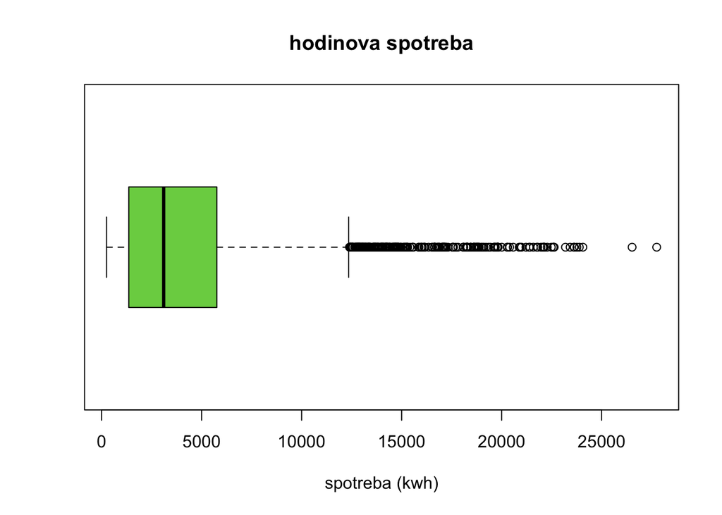

```r
boxplot(spotreba, horizontal = TRUE, col = farby[3],
        main = "hodinova spotreba", xlab = "spotreba (kwh)")
```

```r
length(boxplot.stats(spotreba)$out)
```

```
## [1] 252
```

252 hodnot je oznacenych ako odlahle a maximum dosahuje 27751,57 kwh. samotna odlahlost nie je dokaz chyby, preto tieto hodnoty nevyradujeme.

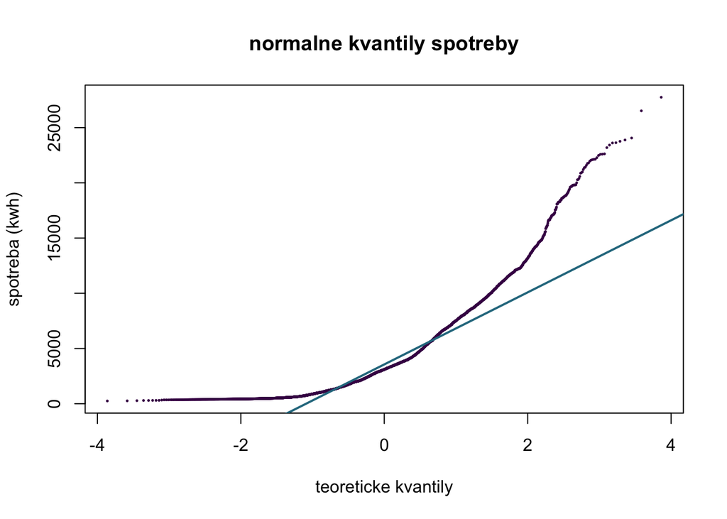

```r
qqnorm(spotreba, pch = 16, cex = 0.35, col = farby[1],
       main = "normalne kvantily spotreby", xlab = "teoreticke kvantily", ylab = "spotreba (kwh)")
qqline(spotreba, col = farby[2], lwd = 2)
```

horne hodnoty sa vyrazne odchyluju od priamky, preto normalne rozdelenie spotreby nie je podlozene.

## casova zavislost

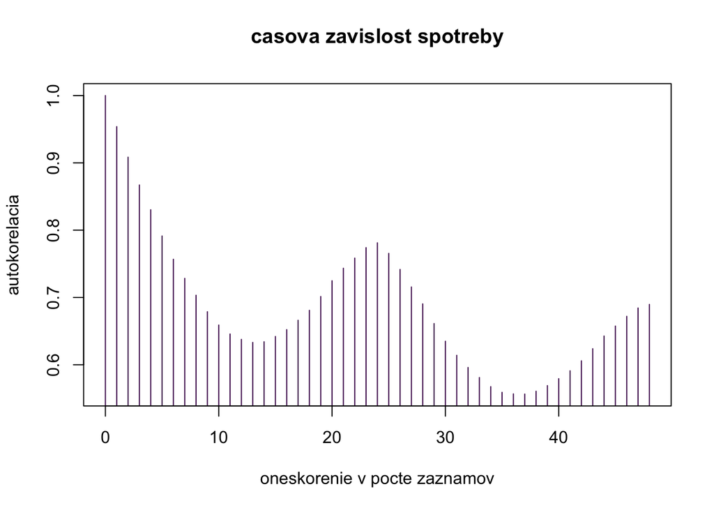

```r
acf_spotreby <- acf(spotreba, lag.max = 48, plot = FALSE)
plot(acf_spotreby, ci = 0, col = farby[1], main = "casova zavislost spotreby",
     xlab = "oneskorenie v pocte zaznamov", ylab = "autokorelacia")
```

```r
as.numeric(acf_spotreby$acf)[c(2, 25)]
```

```
## [1] 0.9538711 0.7812143
```

autokorelacia je 0,954 pri posune o jeden zaznam a 0,781 pri posune o 24 zaznamov. merania nie su nezavisle, preto mozu byt vypocitane intervaly prilis uzke.

## normalita

```r
shapiro.test(sample(spotreba, 5000))
```

```
##
##  Shapiro-Wilk normality test
##
## data:  sample(spotreba, 5000)
## W = 0.84618, p-value < 2.2e-16
```

p-hodnota je mensia ako 0,05, preto normalitu zamietame. vzhladom na casovu zavislost je tento zaver orientacny.

## celkovy priemer

```r
alfa <- 0.05
n <- length(spotreba)
priemer <- mean(spotreba)
is_vzorec <- priemer + c(-1, 1) * qt(1 - alfa / 2, n - 1) * sd(spotreba) / sqrt(n)
is_t <- as.numeric(stats::t.test(spotreba)$conf.int)
is_vzorec
```

```
## [1] 3998.835 4147.383
```

```r
is_t
```

```
## [1] 3998.835 4147.383
```

```r
CI(spotreba)
```

```
##    upper     mean    lower
## 4147.383 4073.109 3998.835
```

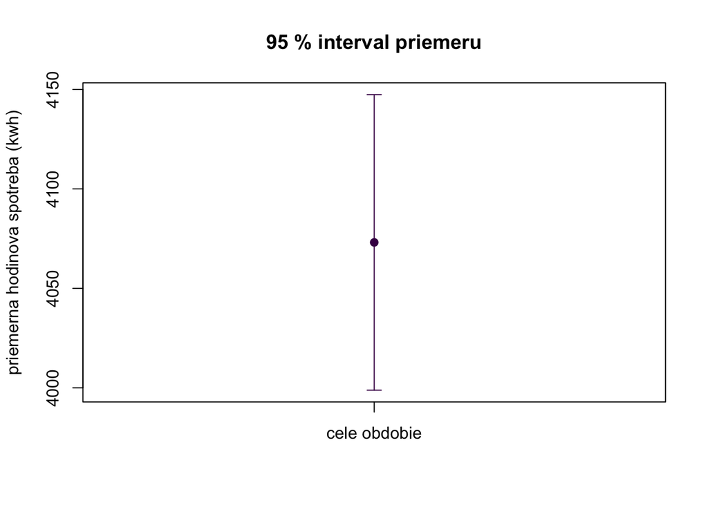

```r
plotCI(1, priemer, li = is_t[1], ui = is_t[2], col = farby[1], pch = 19,
       xaxt = "n", xlab = "", ylab = "priemerna hodinova spotreba (kwh)", main = "95 % interval priemeru")
axis(1, at = 1, labels = "cele obdobie")
```

priemerna hodinova spotreba je 4073,11 kwh a jej 95 % interval je od 3998,84 do 4147,38 kwh. vsetky tri vypocty sa zhoduju, ale interval nevyjadruje rozsah jednotlivych merani.

## hladina spolahlivosti

```r
is_90 <- as.numeric(stats::t.test(spotreba, conf.level = 0.9)$conf.int)
is_90
```

```
## [1] 4010.779 4135.440
```

```r
stats::t.test(spotreba, alternative = "less")$conf.int
```

```
## [1]    -Inf 4135.44
## attr(,"conf.level")
## [1] 0.95
```

```r
stats::t.test(spotreba, alternative = "greater")$conf.int
```

```
## [1] 4010.779      Inf
## attr(,"conf.level")
## [1] 0.95
```

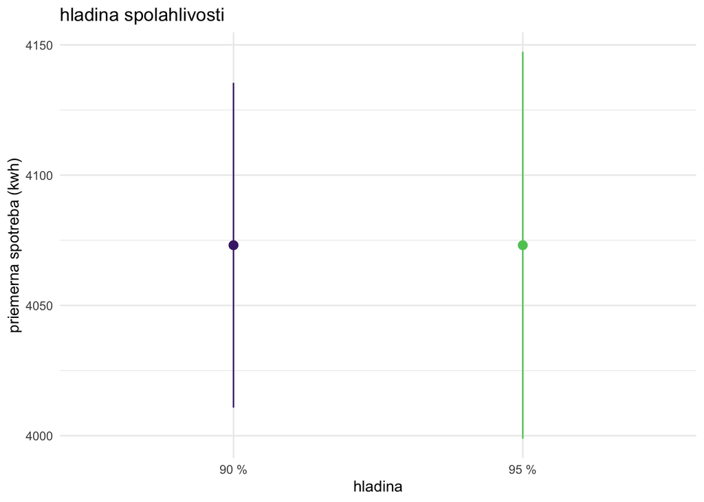

```r
hladiny <- data.frame(hladina = c("90 %", "95 %"), priemer = priemer,
                      dolna = c(is_90[1], is_t[1]), horna = c(is_90[2], is_t[2]))
ggplot(hladiny, aes(hladina, priemer, ymin = dolna, ymax = horna, color = hladina)) +
  geom_pointrange() + scale_color_viridis_d(begin = 0.1, end = 0.75, guide = "none") +
  theme_minimal() + labs(title = "hladina spolahlivosti", x = "hladina", y = "priemerna spotreba (kwh)")
```

90 % interval od 4010,78 do 4135,44 kwh je uzsi nez 95 % interval, pricom priemer zostava rovnaky. jednostranne hranice su 4010,78 a 4135,44 kwh a obmedzuju priemer, nie najvyssiu spotrebu.

## bootstrap

```r
boot_celkovo <- do(10000) * mean(resample(spotreba))
is_boot <- confint(boot_celkovo)
is_boot
```

```
##   name    lower    upper level     method estimate
## 1 mean 4000.166 4148.331  0.95 percentile 4073.109
```

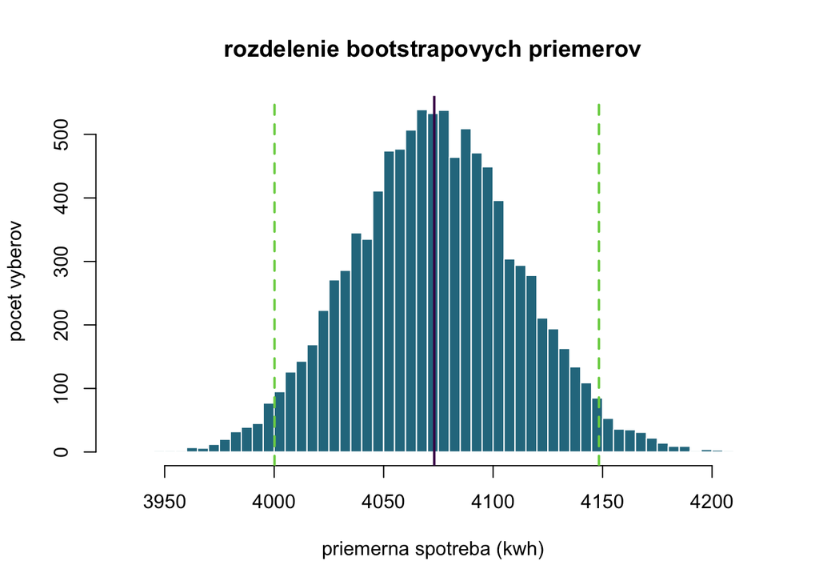

```r
hist(boot_celkovo$mean, breaks = 40, col = farby[2], border = "white",
     main = "rozdelenie bootstrapovych priemerov", xlab = "priemerna spotreba (kwh)", ylab = "pocet vyberov")
abline(v = priemer, col = farby[1], lwd = 2)
abline(v = c(is_boot$lower, is_boot$upper), col = farby[3], lty = 2, lwd = 2)
```

bootstrapove priemery su priblizne symetricke okolo 4073,11 kwh a 95 % interval je od 4000,17 do 4148,33 kwh. blizkost oboch intervalov nepotvrdzuje nezavislost povodnych merani.

## skupinove vypocty

```r
intervaly <- normalita <- grafy <- boot_vybery <- is_tapply <- list()
for (premenna in c("hodina", "den_tyzdna", "typ_dna", "mesiac")) {
  ci <- group.CI(as.formula(paste("spotreba ~", premenna)), data = data)
  names(ci) <- c("skupina", "t_horna", "priemer", "t_dolna")
  ci$skupina <- factor(ci$skupina, levels = levels(data[[premenna]]))
  ci$n <- as.numeric(table(data[[premenna]])[as.character(ci$skupina)])
  ci$boot_dolna <- ci$boot_horna <- NA_real_
  testy <- data.frame(skupina = ci$skupina, n_test = pmin(ci$n, 5000), w = NA_real_, p = NA_real_)
  boot_vybery[[premenna]] <- list()
  is_tapply[[premenna]] <- lapply(tapply(spotreba, data[[premenna]], stats::t.test), "[[", "conf.int")
  for (i in seq_len(nrow(ci))) {
    x <- spotreba[data[[premenna]] == ci$skupina[i]]
    test <- shapiro.test(if (length(x) > 5000) sample(x, 5000) else x)
    testy$w[i] <- unname(test$statistic)
    testy$p[i] <- test$p.value
    boot_data <- do(10000) * mean(resample(x))
    boot_ci <- confint(boot_data)
    ci$boot_dolna[i] <- boot_ci$lower
    ci$boot_horna[i] <- boot_ci$upper
    boot_vybery[[premenna]][[i]] <- boot_data$mean
  }
  intervaly[[premenna]] <- ci
  normalita[[premenna]] <- testy
  graf_data <- rbind(data.frame(skupina = ci$skupina, priemer = ci$priemer,
                                dolna = ci$t_dolna, horna = ci$t_horna, metoda = "t-interval"),
                     data.frame(skupina = ci$skupina, priemer = ci$priemer,
                                dolna = ci$boot_dolna, horna = ci$boot_horna, metoda = "bootstrap"))
  grafy[[premenna]] <- ggplot(graf_data, aes(skupina, priemer, ymin = dolna, ymax = horna, color = metoda)) +
    geom_pointrange(position = position_dodge(0.5)) + scale_color_viridis_d(begin = 0.1, end = 0.75) +
    theme_minimal() + theme(axis.text.x = element_text(angle = 45, hjust = 1), legend.position = "bottom") +
    labs(y = "priemerna hodinova spotreba (kwh)", color = "metoda")
}
```

## hodiny dna

```r
normalita$hodina
```

```
##    skupina n_test         w            p
## 1       00    371 0.8731124 6.927814e-17
## 2       01    370 0.8749453 9.782416e-17
## 3       02    372 0.8778158 1.382653e-16
## 4       03    371 0.8763411 1.154294e-16
## 5       04    371 0.8763386 1.153841e-16
## 6       05    371 0.8777258 1.441069e-16
## 7       06    371 0.8705197 4.628958e-17
## 8       07    371 0.8915198 1.459299e-15
## 9       08    371 0.8826082 3.197764e-16
## 10      09    371 0.8734388 7.291671e-17
## 11      10    371 0.8699476 4.238161e-17
## 12      11    371 0.8453311 1.213720e-18
## 13      12    371 0.8248528 8.563921e-20
## 14      13    371 0.8071300 1.033686e-20
## 15      14    371 0.8043202 7.493166e-21
## 16      15    371 0.8056425 8.714219e-21
## 17      16    371 0.8444785 1.081430e-18
## 18      17    371 0.8683738 3.330011e-17
## 19      18    371 0.8633538 1.564298e-17
## 20      19    371 0.8606957 1.057076e-17
## 21      20    371 0.8608759 1.085353e-17
## 22      21    371 0.8572605 6.421005e-18
## 23      22    371 0.8606929 1.056654e-17
## 24      23    371 0.8610592 1.114921e-17
```

normalitu zamietame vo vsetkych 24 hodinovych skupinach, pretoze ich p-hodnoty su mensie ako 0,05.

```r
intervaly$hodina
```

```
##    skupina  t_horna  priemer  t_dolna   n boot_horna boot_dolna
## 1       00 3678.081 3376.378 3074.675 371   3685.879   3082.593
## 2       01 3749.994 3444.951 3139.909 370   3756.892   3149.161
## 3       02 3868.249 3560.624 3252.999 372   3874.256   3258.824
## 4       03 3860.352 3552.068 3243.784 371   3862.160   3246.018
## 5       04 3856.696 3548.115 3239.534 371   3865.259   3238.862
## 6       05 3855.831 3548.574 3241.317 371   3854.008   3242.310
## 7       06 4622.080 4263.230 3904.380 371   4624.127   3905.200
## 8       07 6124.829 5666.552 5208.274 371   6133.344   5213.996
## 9       08 5907.341 5464.751 5022.160 371   5918.352   5030.936
## 10      09 5682.828 5259.830 4836.833 371   5691.021   4853.457
## 11      10 5546.991 5138.882 4730.773 371   5557.966   4735.287
## 12      11 5890.534 5445.950 5001.367 371   5880.150   5019.583
## 13      12 5158.336 4751.163 4343.990 371   5158.587   4352.877
## 14      13 5040.692 4632.213 4223.734 371   5050.547   4237.661
## 15      14 4880.277 4479.893 4079.510 371   4880.952   4081.098
## 16      15 4791.201 4395.020 3998.839 371   4809.634   4005.412
## 17      16 4311.023 3966.351 3621.679 371   4314.182   3629.444
## 18      17 3803.245 3502.543 3201.841 371   3808.024   3205.887
## 19      18 3521.763 3233.090 2944.416 371   3522.141   2946.592
## 20      19 3533.729 3239.705 2945.682 371   3538.437   2945.848
## 21      20 3561.212 3264.071 2966.931 371   3566.243   2975.729
## 22      21 3598.385 3295.526 2992.666 371   3605.049   2998.910
## 23      22 3639.259 3334.023 3028.788 371   3635.602   3043.782
## 24      23 3700.375 3390.803 3081.232 371   3708.573   3090.836
```

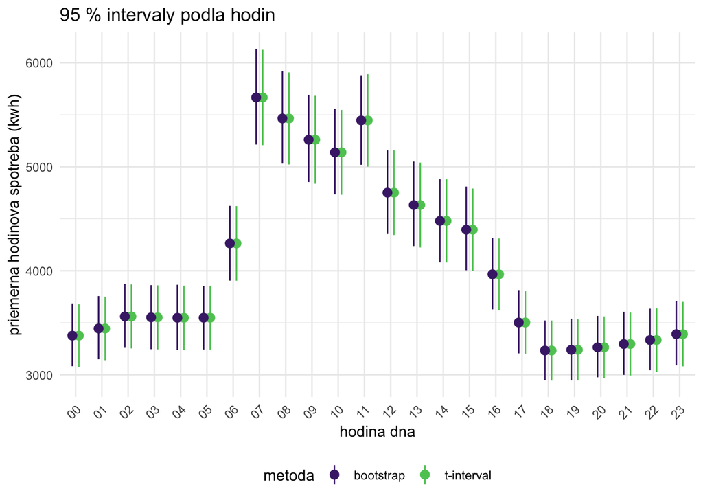

```r
grafy$hodina + labs(title = "95 % intervaly podla hodin", x = "hodina dna")
```

najvyssi priemer je o 07. hodine s 5666,55 kwh a najnizsi o 18. hodine s 3233,09 kwh, ich intervaly sa neprekryvaju. susedne hodiny maju casto prekryvajuce sa intervaly a obe metody poskytuju podobne vysledky.

## dni v tyzdni

```r
normalita$den_tyzdna
```

```
##    skupina n_test         w            p
## 1 pondelok   1272 0.8277041 6.493062e-35
## 2   utorok   1272 0.8494709 3.974682e-33
## 3   streda   1272 0.8886227 2.555760e-29
## 4  stvrtok   1272 0.8635131 7.313830e-32
## 5   piatok   1272 0.8474496 2.660823e-33
## 6   sobota   1272 0.8268693 5.592325e-35
## 7   nedela   1272 0.8505013 4.884906e-33
```

normalitu zamietame vo vsetkych siedmich dnoch tyzdna, pretoze ich p-hodnoty su mensie ako 0,05.

```r
intervaly$den_tyzdna
```

```
##    skupina  t_horna  priemer  t_dolna    n boot_horna boot_dolna
## 1 pondelok 4676.497 4461.062 4245.627 1272   4683.250   4250.309
## 2   utorok 4651.604 4443.300 4234.995 1272   4652.093   4241.264
## 3   streda 4706.970 4506.795 4306.621 1272   4707.953   4308.849
## 4  stvrtok 4508.430 4308.345 4108.260 1272   4516.176   4112.714
## 5   piatok 4205.269 4009.141 3813.013 1272   4206.591   3817.791
## 6   sobota 3672.308 3491.645 3310.982 1272   3672.285   3309.295
## 7   nedela 3450.950 3291.476 3132.002 1272   3449.330   3134.541
```

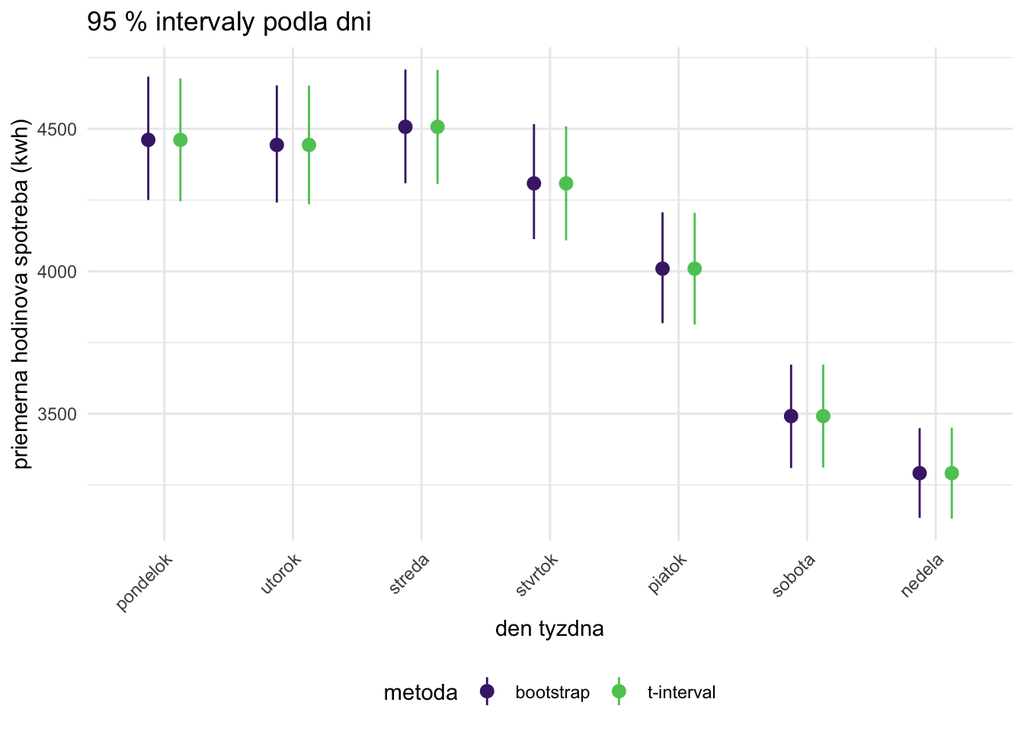

```r
grafy$den_tyzdna + labs(title = "95 % intervaly podla dni", x = "den tyzdna")
```

najvyssi priemer ma streda s 4506,80 kwh a najnizsi nedela s 3291,48 kwh, ich intervaly sa neprekryvaju. intervaly blizkych pracovnych dni sa prekryvaju, preto z nich nemozno jednoznacne urcit poradie skutocnych priemerov.

## pracovne dni a vikendy

```r
normalita$typ_dna
```

```
##        skupina n_test         w            p
## 1 pracovny den   5000 0.8578180 2.570471e-55
## 2       vikend   2544 0.8378098 3.582420e-45
```

normalitu zamietame pri pracovnych dnoch aj vikendoch, pretoze obe p-hodnoty su mensie ako 0,05.

```r
intervaly$typ_dna
```

```
##        skupina  t_horna  priemer  t_dolna    n boot_horna boot_dolna
## 1 pracovny den 4437.034 4345.729 4254.423 6360   4436.447   4255.902
## 2       vikend 3512.032 3391.561 3271.089 2544   3511.266   3274.254
```

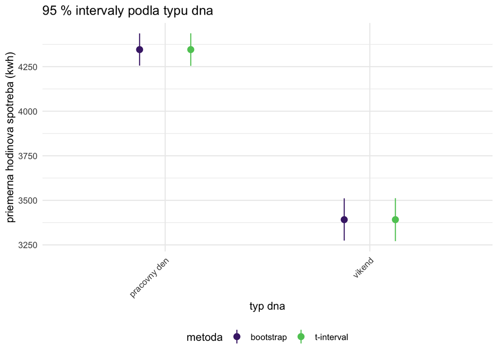

```r
grafy$typ_dna + labs(title = "95 % intervaly podla typu dna", x = "typ dna")
```

```r
rozdiel_typ <- diff(rev(intervaly$typ_dna$priemer))
percento_typ <- 100 * rozdiel_typ / intervaly$typ_dna$priemer[2]
c(rozdiel_kwh = rozdiel_typ, rozdiel_percent = percento_typ)
```

```
##     rozdiel_kwh rozdiel_percent
##        954.1680         28.1336
```

priemer pracovnych dni je 4345,73 kwh a vikendov 3391,56 kwh, rozdiel je 954,17 kwh alebo 28,13 % oproti vikendu. intervaly sa neprekryvaju a vyrazna vikendova spotreba poukazuje na pretrvavajuce odbery aj mimo pracovnych dni.

## mesiace

```r
normalita$mesiac
```

```
##    skupina n_test         w            p
## 1  2022-12    744 0.9331723 1.004779e-17
## 2  2023-01    744 0.8416409 1.434018e-26
## 3  2023-02    672 0.8466934 5.706549e-25
## 4  2023-03    744 0.9449141 5.261419e-16
## 5  2023-04    720 0.9528279 2.049049e-14
## 6  2023-05    744 0.9356545 2.219956e-17
## 7  2023-06    720 0.8992103 2.425222e-21
## 8  2023-07    744 0.7573424 1.181176e-31
## 9  2023-08    744 0.8154791 2.449607e-28
## 10 2023-09    720 0.8452223 6.581897e-26
## 11 2023-10    744 0.8557594 1.608450e-25
## 12 2023-11    720 0.9308021 1.000061e-17
## 13 2023-12    144 0.8824638 2.640376e-09
```

normalitu zamietame vo vsetkych 13 mesacnych skupinach, pretoze ich p-hodnoty su mensie ako 0,05.

```r
intervaly$mesiac
```

```
##    skupina  t_horna  priemer  t_dolna   n boot_horna boot_dolna
## 1  2022-12 7008.153 6775.009 6541.864 744   7010.971   6545.144
## 2  2023-01 8711.022 8443.967 8176.913 744   8712.597   8183.189
## 3  2023-02 7895.547 7515.879 7136.212 672   7892.981   7140.666
## 4  2023-03 6848.434 6605.254 6362.075 744   6849.117   6363.948
## 5  2023-04 3311.567 3226.841 3142.115 720   3311.058   3142.210
## 6  2023-05 2842.826 2754.162 2665.497 744   2843.490   2667.761
## 7  2023-06 1543.983 1475.707 1407.432 720   1543.494   1409.938
## 8  2023-07 1252.327 1183.575 1114.824 744   1254.345   1114.750
## 9  2023-08 1242.991 1178.746 1114.501 744   1241.544   1116.363
## 10 2023-09 1164.991 1112.714 1060.437 720   1166.508   1060.067
## 11 2023-10 3494.355 3327.982 3161.608 744   3495.560   3161.075
## 12 2023-11 5150.945 5021.068 4891.190 720   5150.367   4891.905
## 13 2023-12 6460.880 6209.902 5958.924 144   6465.429   5964.096
```

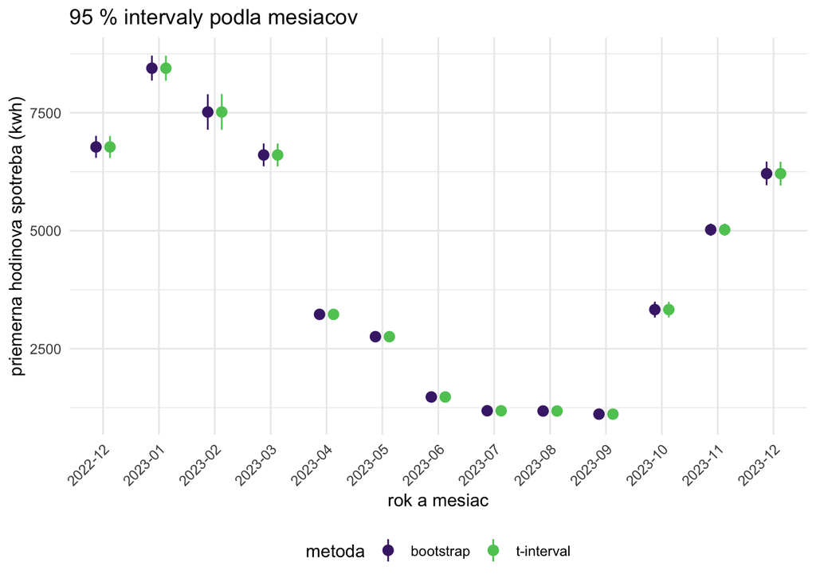

```r
grafy$mesiac + labs(title = "95 % intervaly podla mesiacov", x = "rok a mesiac")
```

najvyssi priemer ma januar 2023 s 8443,97 kwh a najnizsi september 2023 s 1112,71 kwh, ich intervaly sa neprekryvaju. december 2023 ma iba 144 merani a jeho priemer neopisuje cely mesiac, preto nie je rovnocenny decembru 2022.

# zaver

najvyssia priemerna zataz je rano, pocas pracovnych dni a v zimnej casti sledovaneho obdobia. casova zavislost moze intervaly zuzit a samotny prekryv ani neprekryv intervalov nenahradza test rozdielu priemerov. intervaly opisuju neistotu priemeru, nie buduce spicky spotreby.